# Praca domowa 2

Daminika Dzeranhouskaya

## Dane

Dane wykorzystane w Pracy domowej 2 opisują wycenę nieruchmości. Każda obserwacja jest pewną nieruchmością, która posiada informacje takie jak powierzchnia, liczba pokoi, liczba łazienek i wiele więcj. Opis wszystkich kolumn w pliku `README.md`.

## Zadanie 1

Jak wygląda rozkład ceny nieruchomości w poszczególnych kodach pocztowych na przestrzeni lat? Rozważamy kody pocztowe, które mają więcej niż 280 posiadłości.

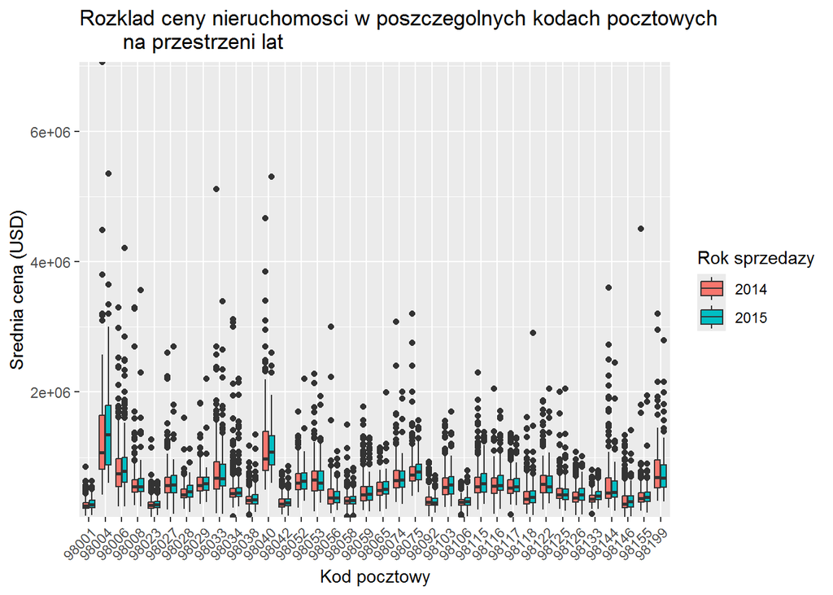

```r
# Tu umieść kod do wygenerowania odpowiedzi do zadania.

df_1 <- df %>% group_by(zipcode) %>%
  filter(n()>280) %>%
  mutate(year = substr(date, 1,4),
         zipcode = as.character(zipcode)
           ) %>%
  group_by(zipcode, year)

ggplot(df_1, aes(y = price, x = zipcode, fill = year)) +
  geom_boxplot() +
  scale_x_discrete(guide=guide_axis(n.dodge = 1, angle=45)) +
  scale_y_continuous(expand = c(0, 0)) +
  labs(x = "Kod pocztowy", y = "Średnia cena (USD)", fill = "Rok sprzedazy",
       title = "Rozkład ceny nieruchomości w poszczególnych kodach pocztowych
       na przestrzeni lat")
```

**Komentarz:** Dla większości kodów pocztowych widać wzrost cen między 2014 a 2015 rokiem, co może świadczyć o poprawie sytuacji na rynku nieruchomości. Istnieje jednak kilka kodów pocztowych, gdzie cena nie zmieniła się znacząco lub nawet nieco spadła. Niektóre kody pocztowe wykazują bardzo wysokie ceny nieruchomości (np. 98004), co sugeruje ich prestiżowość lub atrakcyjne położenie. Na wykresie widać duże zróżnicowanie cenowe dla róznych kodów pocztowych, więc cena zależy od lokalizacji.

## Zadanie 2

Czy jest różnica w rozkładzie ceny nierchomości od powierzchni mieszkalnej uwzględniając podział na nieruchomości z piwnicą i bez?

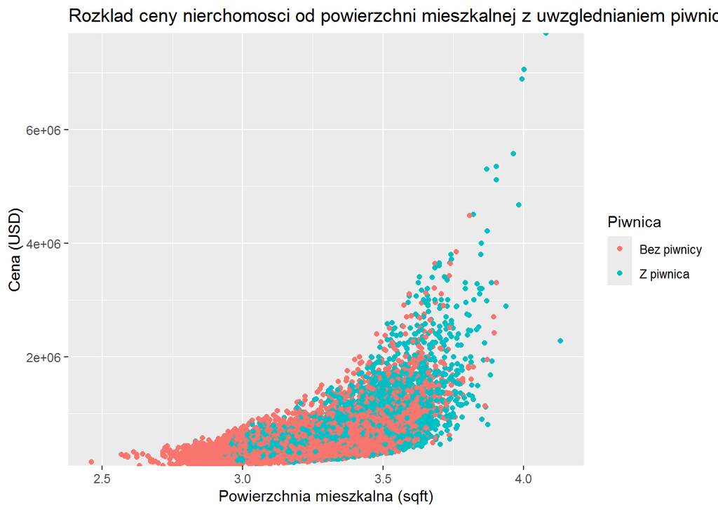

```r
# Tu umieść kod do wygenerowania odpowiedzi do zadania.

df_2 <- df %>% mutate(basement = ifelse(sqft_basement==0,"Bez piwnicy","Z piwnica" ))


ggplot(df_2, aes(x = log10(sqft_living), y = price, colour = basement)) +
  geom_point() +
  scale_y_continuous(expand = c(0, 0)) +
  labs(x = "Powierzchnia mieszkalna (sqft)", y = "Cena (USD)", colour = "Piwnica",
       title = "Rozkład ceny nierchomości od powierzchni mieszkalnej z uwzglednianiem piwnicy")
```

**Komentarz:** Wykres pokazuje, że zarówno powierzchnia mieszkalna, jak i obecność piwnicy wpływają na cenę nieruchomości. W miarę wzrostu powierzchni mieszkalnej ceny rosną, a obecność piwnicy dodatkowo podnosi wartość nieruchomości, zwłaszcza w wyższych przedziałach cenowych.

## Zadanie 3

Jaka jest zależność pomiędzy jakością wykończenia nieruchomości a liczbą pięter?

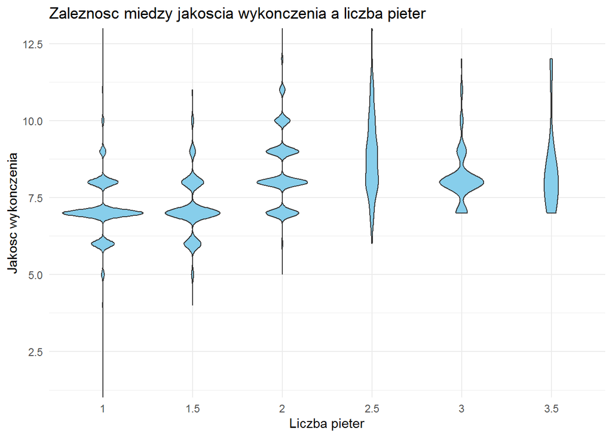

```r
# Tu umieść kod do wygenerowania odpowiedzi do zadania.
ggplot(df, aes(x = as.factor(floors), y = grade))+
  geom_violin(fill = "skyblue") +
  scale_y_continuous(expand = c(0, 0)) +
  labs(title = "Zależność między jakością wykończenia a liczbą pięter",
       x = "Liczba pięter",
       y = "Jakość wykończenia") + theme_minimal()
```

## Zadanie 4

Jaka jest zależność między powierzchnią mieszkalną nieruchomości a powierzchnią gruntu w podziale na liczbę sypialni?

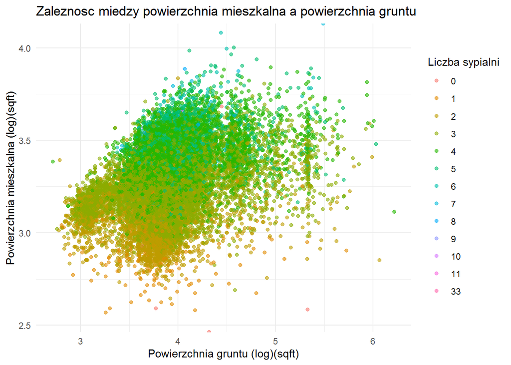

```r
# Tu umieść kod do wygenerowania odpowiedzi do zadania.

ggplot(df, aes(x = log10(sqft_lot), y = log10(sqft_living), color = as.factor(bedrooms))) +
  geom_point(alpha = 0.6) +
  scale_y_continuous(expand = c(0, 0)) +
  labs(title = "Zależność między powierzchnią mieszkalną a powierzchnią gruntu",
       x = "Powierzchnia gruntu (log)(sqft)",
       y = "Powierzchnia mieszkalna (log)(sqft)",
       color = "Liczba sypialni") + theme_minimal()
```

**Komentarz:** Wraz ze wzrostem powierzchni gruntu, powierzchnia mieszkalna również rośnie, ale jest to zależność umiarkowana, szczególnie dla mniejszych działek. Liczba sypialni ma istotny wpływ na powierzchnię mieszkalną – im więcej sypialni, tym większa powierzchnia mieszkalna. Jednak liczba sypialni nie zawsze jest jednoznacznie związana z wielkością działki, co sugeruje, że wiele dużych nieruchomości może być budowanych na mniejszych działkach, szczególnie w miejscach o dużej gęstości zaludnienia.

## Zadanie 5

Rozważmy tylko nieruchomości, które miały remont. W której dekadzie było najwięcej przeprowadzonych remontów? Czy w poszczególnych dekadach jest porównywalny procent nieruchmości dla każdej wartości miary jakości i wykończenia nieruchomości?

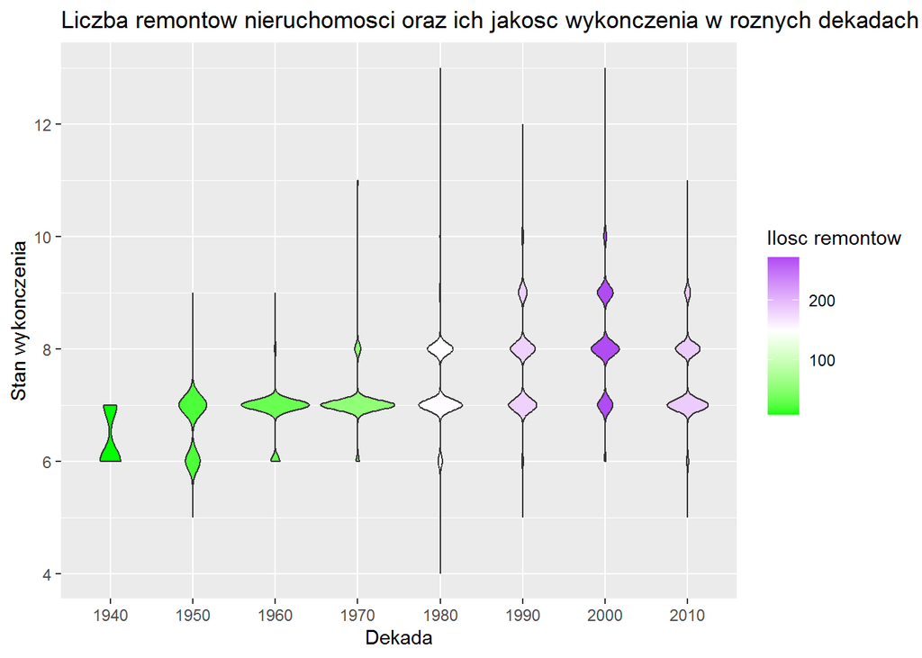

```r
# Tu umieść kod do wygenerowania odpowiedzi do zadania.


df_5<-df %>%
    filter(yr_renovated!=0) %>%
    mutate(dekada=as.character(floor(yr_renovated/10)*10))

pom<-df_5 %>%
    group_by(dekada) %>%
    reframe(ilosc_remontow=n(),grade)

df_5 <- df_5 %>%
    inner_join(pom, relationship = "many-to-many") %>%
    filter(dekada!="1930")

df_5 %>%
    ggplot(aes(x=dekada,y=grade,fill=ilosc_remontow))+
    geom_violin()+
    scale_fill_gradient2(low = "green", mid = "white", high = "purple", midpoint = 150)+
    labs(y="Stan wykończenia",x="Dekada",fill="Ilość remontów", title = "Liczba remontów nieruchomości oraz ich jakość wykończenia w różnych dekadach")
```

## Zadanie 6

Jak prezentuje się wartość minimalna, średnia i maksymalna ceny nieruchmości w podziele na rok budowy nieruchomości.

[figure not shown]

```r
# Tu umieść kod do wygenerowania odpowiedzi do zadania.

df_6 <- df %>% group_by(yr_built) %>%
  summarise(min_price = min(price),
            median_price = median(price),
            max_price = max(price))
ggplot(df_6, aes(x = yr_built)) +
  geom_line(aes(y = min_price, color = "Minimalna cena"), linewidth = 1) +
  geom_line(aes(y = median_price, color = "Średnia cena"), linewidth = 1) +
  geom_line(aes(y = max_price, color = "Maksymalna cena"), linewidth = 1) +
  labs(title = "Minimalna, średnia i maksymalna cena nieruchomości w podziale na rok budowy",
       x = "Rok budowy",
       y = "Cena nieruchomości (USD)",
       color = "Statystyka")
```